# Assignment

## Data preparation

We start with reading the data and investigating its dimensions.

```r
# read data
train <- read.csv(paste(inp_path, "pml-training.csv", sep ="/"))
test <- read.csv(paste(inp_path, "pml-testing.csv", sep ="/"))

# quick exploration
dim(train)
```

```
## [1] 19622   160
```

```r
dim(test)
```

```
## [1]  20 160
```

Although, training and test set have the same columns, many of the values in the test set are NA. As the goal is to make predictions on the test set we shall exclude variables which have missing values in the test set.

```r
opt <- "exclude_cols"

### Subset data -> data which are mostly NA in train and always NA in test
# Check if any variable of type logical in train -> no
for (i in 1:ncol(train)){
  if(sapply(train, class)[i]=="logical"){
    print(names(train)[i])
  }
}
# extracting vector of names of variables of type logical in test (=variables which are all NA)
exclude <- c()
for (i in 1:ncol(test)){
  if(sapply(test, class)[i]=="logical"){
    exclude <- c(exclude, names(test)[i])
  }
}
# add redundant variables to vector
exclude <- c(exclude, names(test)[1])
# excluding variables of type logical from train and test
if(opt=="exclude_cols"){
  train <- train[,!(colnames(train) %in% exclude)]
  test <- test[,!(colnames(test) %in% exclude)]
}
```

Finally, we re-split the training set into training and validation set, in order to obtain unbiased accuracy measures on our models.

```r
set.seed(98332)
train_tmp <- train
inTrain <- createDataPartition(y=train_tmp$classe,
                               p=0.7, list=F)
train <- train_tmp[inTrain,]
valid <- train_tmp[-inTrain,]
rm(train_tmp)
```

## Data Exploration

Now we have a closer look at the data. We plot histograms for the user_name and classe variable as well as a cross-table including both variables:

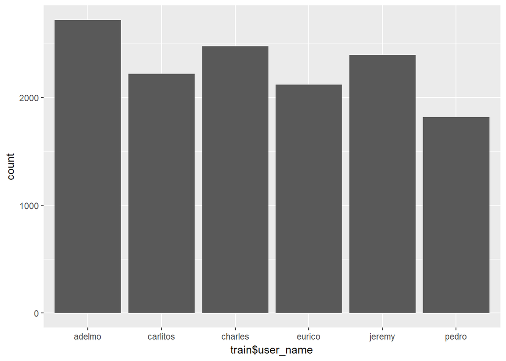

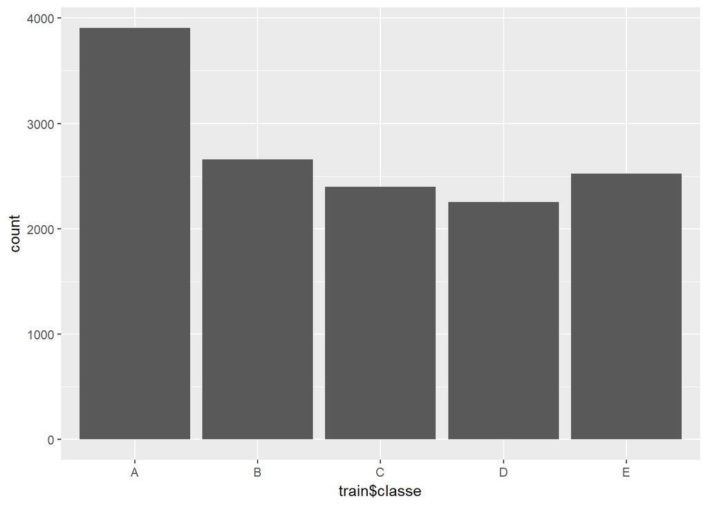

|  | A | B | C | D | E |
| --- | --- | --- | --- | --- | --- |
| adelmo | 815 | 541 | 529 | 355 | 478 |
| carlitos | 600 | 490 | 343 | 360 | 425 |
| charles | 606 | 525 | 394 | 454 | 495 |
| eurico | 586 | 400 | 338 | 407 | 386 |
| jeremy | 845 | 346 | 446 | 360 | 396 |
| pedro | 454 | 356 | 346 | 316 | 345 |

We see that the data set is balanced in terms of user_name and not too unbalanced regarding the response variable. Furthermore, the different responses (A to E) seem to be quite evenly distributed accross user_names.

## Building Models

We will train 3 different models that are suited to deal with multinomial classification problems:

- Penalized Multinomial Regression
- SVM
- Random Forest

We expect the best accuracy for random forest as it is very well suited to deal with multiclass classification problems especially when we have continuous as well as categorical variables as potential predictors. For each model we use 10-fold cross-validation with 3 repeats and investigate the model performance on the validation set. In order to save computing time, we pre-calculated the models and simply load them in this RMD-file. Hence, the code for the model calculation is out-commented in the following blocks.

We start with the Penalized Multinomial Regression model:

```
## Penalized Multinomial Regression
##
## 13737 samples
##    58 predictor
##     5 classes: 'A', 'B', 'C', 'D', 'E'
##
## No pre-processing
## Resampling: Cross-Validated (10 fold, repeated 3 times)
## Summary of sample sizes: 12362, 12364, 12364, 12366, 12362, 12363, ...
## Resampling results across tuning parameters:
##
##   decay  Accuracy   Kappa
##   0e+00  0.6630014  0.5724123
##   1e-04  0.6657447  0.5758559
##   1e-03  0.6627607  0.5721724
##   1e-02  0.6584680  0.5664552
##   1e-01  0.6627853  0.5719782
##
## Accuracy was used to select the optimal model using the largest value.
## The final value used for the model was decay = 1e-04.
```

```
## Confusion Matrix and Statistics
##
##           Reference
## Prediction    A    B    C    D    E
##          A 1321  142  139   87   98
##          B  119  736  112   60  166
##          C   97  119  636  116   87
##          D  100   42   96  623   90
##          E   37  100   43   78  641
##
## Overall Statistics
##
##                Accuracy : 0.6724
##                  95% CI : (0.6602, 0.6844)
##     No Information Rate : 0.2845
##     P-Value [Acc > NIR] : < 2.2e-16
##
##                   Kappa : 0.5846
##  Mcnemar's Test P-Value : 4.033e-12
##
## Statistics by Class:
##
##                      Class: A Class: B Class: C Class: D Class: E
## Sensitivity            0.7891   0.6462   0.6199   0.6463   0.5924
## Specificity            0.8893   0.9037   0.9138   0.9333   0.9463
## Pos Pred Value         0.7392   0.6169   0.6028   0.6551   0.7130
## Neg Pred Value         0.9139   0.9141   0.9193   0.9309   0.9116
## Prevalence             0.2845   0.1935   0.1743   0.1638   0.1839
## Detection Rate         0.2245   0.1251   0.1081   0.1059   0.1089
## Detection Prevalence   0.3037   0.2027   0.1793   0.1616   0.1528
## Balanced Accuracy      0.8392   0.7749   0.7668   0.7898   0.7694
```

The accuracy is not that high at 67%.

Second we try an svm model:

[output not shown]

```
## Confusion Matrix and Statistics
##
##           Reference
## Prediction    A    B    C    D    E
##          A 1608   87  112   31   73
##          B   61  868  322   18    0
##          C    4  184  539  110   19
##          D    0    0   53  701   59
##          E    1    0    0  104  931
##
## Overall Statistics
##
##                Accuracy : 0.7896
##                  95% CI : (0.779, 0.8)
##     No Information Rate : 0.2845
##     P-Value [Acc > NIR] : < 2.2e-16
##
##                   Kappa : 0.7322
##  Mcnemar's Test P-Value : NA
##
## Statistics by Class:
##
##                      Class: A Class: B Class: C Class: D Class: E
## Sensitivity            0.9606   0.7621  0.52534   0.7272   0.8604
## Specificity            0.9280   0.9155  0.93476   0.9772   0.9781
## Pos Pred Value         0.8414   0.6840  0.62967   0.8622   0.8986
## Neg Pred Value         0.9834   0.9413  0.90316   0.9481   0.9689
## Prevalence             0.2845   0.1935  0.17434   0.1638   0.1839
## Detection Rate         0.2732   0.1475  0.09159   0.1191   0.1582
## Detection Prevalence   0.3247   0.2156  0.14545   0.1381   0.1760
## Balanced Accuracy      0.9443   0.8388  0.73005   0.8522   0.9193
```

The last model we try is the computationally quite expensive Random Forest:

```
## Confusion Matrix and Statistics
##
##           Reference
## Prediction    A    B    C    D    E
##          A 1672    2    0    0    0
##          B    2 1137    9    0    0
##          C    0    0 1017    7    0
##          D    0    0    0  957    1
##          E    0    0    0    0 1081
##
## Overall Statistics
##
##                Accuracy : 0.9964
##                  95% CI : (0.9946, 0.9978)
##     No Information Rate : 0.2845
##     P-Value [Acc > NIR] : < 2.2e-16
##
##                   Kappa : 0.9955
##  Mcnemar's Test P-Value : NA
##
## Statistics by Class:
##
##                      Class: A Class: B Class: C Class: D Class: E
## Sensitivity            0.9988   0.9982   0.9912   0.9927   0.9991
## Specificity            0.9995   0.9977   0.9986   0.9998   1.0000
## Pos Pred Value         0.9988   0.9904   0.9932   0.9990   1.0000
## Neg Pred Value         0.9995   0.9996   0.9981   0.9986   0.9998
## Prevalence             0.2845   0.1935   0.1743   0.1638   0.1839
## Detection Rate         0.2841   0.1932   0.1728   0.1626   0.1837
## Detection Prevalence   0.2845   0.1951   0.1740   0.1628   0.1837
## Balanced Accuracy      0.9992   0.9980   0.9949   0.9963   0.9995
```

The model improves a lot with an accuracy of close to 100%.

## Conclusion

Out of the three investigated model the best performing one is random forest with highest Accuracy and Kappa.

| model | Accuracy | Kappa |
| --- | --- | --- |
| glm | 0.6723874 | 0.5845535 |
| svm | 0.7896347 | 0.7322038 |
| rf | 0.9964316 | 0.9954862 |

Finally we plot the 9 most relevant predictors:

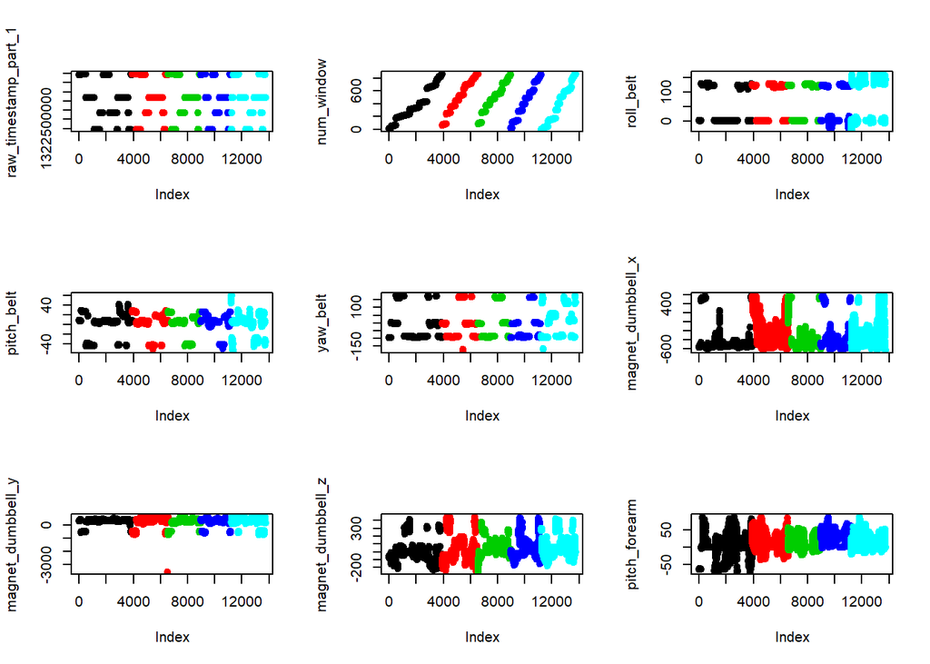

## Prediction on Test Set

Now we may use the Random Forest model make predictions on the test set:

```r
predictions_rf <- predict(mod_rf, test)
predictions_rf
```

```
##  [1] B A B A A E D B A A B C B A E E A B B B
## Levels: A B C D E
```